# Cosy analysis

Louise Bernard

2024-03-18

## Introduction

This document presents the results of the impact of the adoption of cosy tariff on smart meter electricity consumption at the household level.

In summary, switching to the Cosy rate appears to effectively encourage customers to increase their electricity consumption during incentivised periods (cosy morning and afternoon) while decreasing usage during peak and other times, with an overall slight increase in daily consumption.

Done:

- Add weather [done - but using reanalysis data, the MET data from databricks only starts in 2022]: I decided to use GSP* date trends instead
- Implement Callaway and sant’anna DiD [done but more work needed on the panel balance]: I have settled on almost a year but could restrict further
- Decide of a threshold for the event study (how many weeks before / after adoption we want to capture, do we want to put all weeks before in a large category or exclude them)

To do:

- Can we find out when they install their HP
- heterogeneity: epc data, what tariff they were on before
- calculate price elasticities
- calculate emissions savings
- show number of adoption per month

## Descriptive statistics on cosy adoption

The Cosy tariff has 4 different periods:

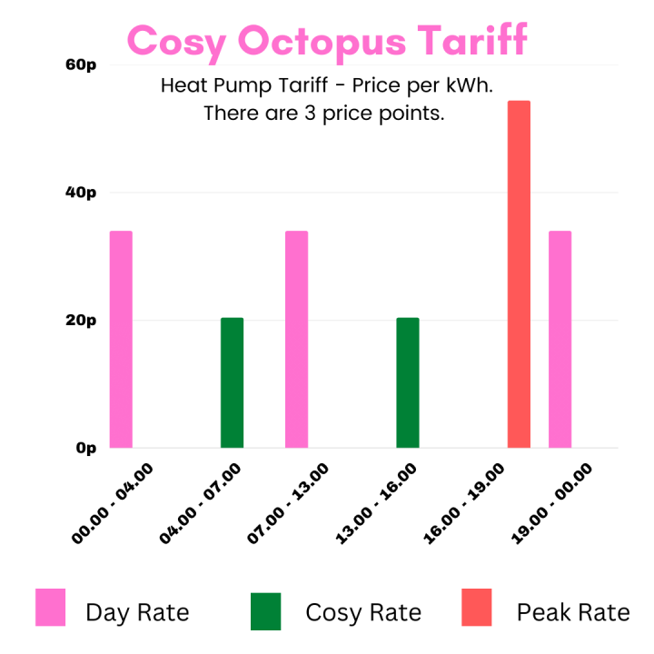

This bar chart shows average consumption pre and post cosy for each period of the day:

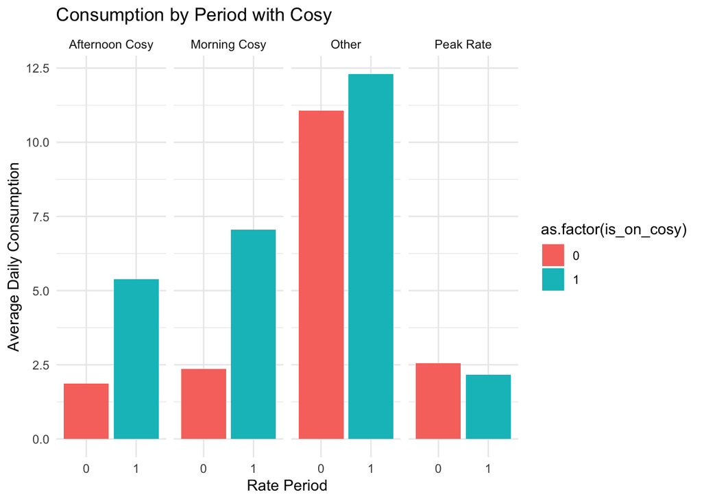

## Difference in differences

We run the following model by period and on total daily consumption for all customers that have adopted Cosy in the past year:

$$Consumption_{it} = \alpha OnCosy_{it} +
\delta_t + \gamma_i + GSP \times \delta_t+ \epsilon_{it}$$
with:

- $Consumption_{it}$ - electricty consumption in kWh (Table 1) and as share of daily consumption (Table 2) for customer $i$ on day $t$
- $OnCosy_{it}$ a dummy variable equals 1 if the customer has switched to Cosy, 0 otherwise [^1]
- $\delta_t$, $\gamma_i$, $ GSP _t$ are day $t$, customer $i$, and GSP regions times day fixed effects The standard errors are clustered at the customer (MPAN) level.

### Consumption by period

All of these coefficients are statistically significant at the 1 percent significance level.

In summary, switching to the Cosy rate appears to effectively encourage customers to increase their electricity consumption during incentivised periods (cosy morning and afternoon) while decreasing usage during peak and other times, with an overall slight increase in daily consumption.

### Share electricity consumption

The table’s analysis shows how adopting the Cosy rate plan impacts customers’ electricity usage patterns across different times of the day, focusing on the change in the share of daily electricity consumption per period.

- **Afternoon Cosy Period:** After switching to the Cosy rate, the proportion of electricity used during the afternoon cosy period increased by 6.62 percentage points. This indicates customers are more inclined to consume electricity during these hours under the Cosy rate.
- **Morning Cosy Period:** The adoption of the Cosy rate led to an even more pronounced increase in electricity use during the morning cosy period, with a 12.56 percentage point rise in its share of daily consumption. This suggests a significant behavioral shift towards consuming more electricity in the morning hours.
- **Other Times:** Contrarily, there’s a decrease in the share of electricity consumption during times not designated as cosy by 14.71 percentage points, reflecting a shift away from electricity usage during these periods.
- **Peak Rate Times:** The share of daily electricity usage during peak rate times also saw a decrease, falling by 4.75 percentage points. This reduction implies that consumers are adjusting their usage to avoid higher-cost periods.

  ```
                                   m1.1               m1.2
  ```

  Sample (rate_period) Afternoon Cosy Morning Cosy Dependent Var.: share_consumption share_consumption

as.factor(is_on_cosy)1 0.0662*** (0.0018) 0.1256*** (0.0031) Fixed-Effects: —————— —————— date Yes Yes mpan Yes Yes date-tariff_gsp_group_id Yes Yes ________________________ __________________ __________________ S.E.: Clustered by: mpan by: mpan Observations 1,532,241 1,531,188 R2 0.37382 0.45001 Within R2 0.03228 0.06531

```
                                    m1.3                m1.4
```

Sample (rate_period) Other Peak Rate Dependent Var.: share_consumption share_consumption

as.factor(is_on_cosy)1 -0.1471*** (0.0038) -0.0475*** (0.0012) Fixed-Effects: ——————- ——————- date Yes Yes mpan Yes Yes date-tariff_gsp_group_id Yes Yes ________________________ ___________________ ___________________ S.E.: Clustered by: mpan by: mpan Observations 1,535,366 1,532,342 R2 0.41619 0.34651 Within R2 0.06009 0.02380 — Signif. codes: 0 ‘**’ 0.001 ’**’ 0.01 ’’ 0.05 ‘.’ 0.1 ’ ’ 1

## Event study

We run the following model by period for all customers that have adopted Cosy in the past year:

$$Consumption_{it} = \sum^W _{w={-52, -9,
..., 1, ..,52}} \alpha_w WeeksSinceCosy^w_{it} + X\beta + \delta_t
+ \gamma_i + \epsilon_{it}$$
where: - $WeeksSinceCosy^w_{it}$ is a categorical variable equals to the number of weeks before and after the adoption of Cosy. We use the week prior adoption as omitted category.

### Consumption by period

The charts show the event study coefficients for each specified period. We find that coefficients are consistent with those from the difference-in-differences analysis.

Interestingly, the trend for the Morning Cosy period doesn’t appear to be as stable, almost indicating an overall decrease in consumption over time, with still a noticeable jump at the point of adoption. This pattern suggests that the interaction between time trends and the effects of the treatment might be more pronounced during the Morning Cosy period than in other periods or something as the unbalanced panel data.

Similarly, the coefficients on Afternoon Cosy pre -adoption are consistently negative - I think we could improve this part of the analysis.

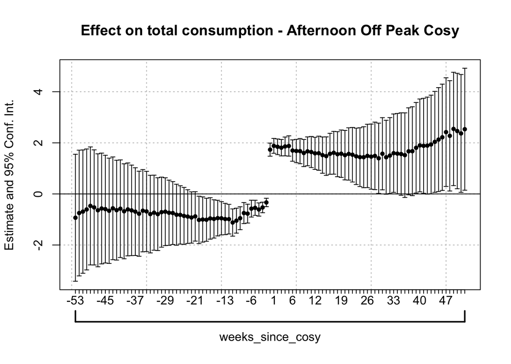

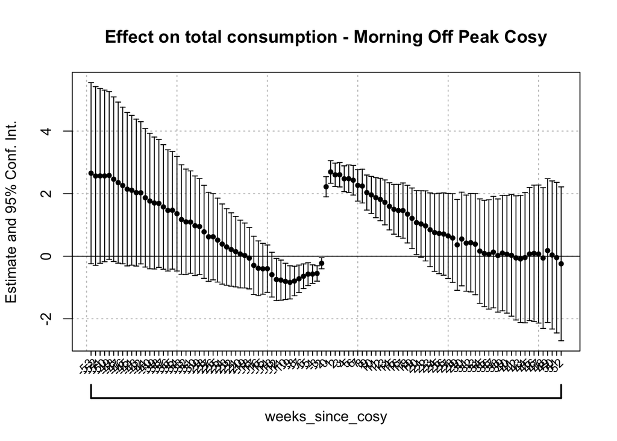

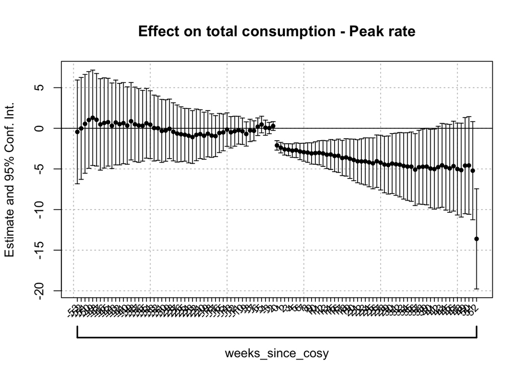

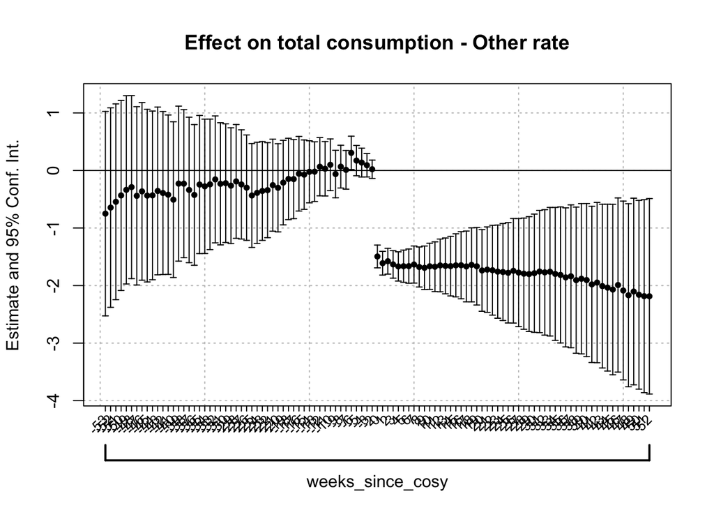

## Callaway Sant’Anna DiD

This estimator refines traditional DiD analyses by offering more robust handling of heterogeneous treatment effects over time. The data aggregation at the week level necessitates adjustment (division by 7) for direct comparison with previous estimations, which were at a daily granularity. This aggregation may smooth out some of the daily volatility but still captures broader trends.

**Key Components Analyzed**

### Overall ATT (Average Treatment Effect on the Treated)

This measures the average impact of the Cosy rate on all treated customers.

To compare the recently calculated daily coefficients with the previous coefficients provided, let’s line them up:

Previous Coefficients (per period):

- **Afternoon Cosy:** +1.770 kWh
- **Morning Cosy:** +3.079 kWh
- **Other:** -2.664 kWh
- **Peak Rate:** -1.204 kWh
- **Overall:** +1.073 kWh (Overall daily consumption increase)

Recently Calculated Daily Coefficients:

- **Afternoon Cosy:** +2.33 kWh/day
- **Morning Cosy:** +3.41 kWh/day
- **Other:** -2.61 kWh/day
- **Peak Rate:** -1.34 kWh/day
- **Overall:** +1.79 kWh/day

The comparison shows that the Callaway and Sant’Anna coefficients generally indicate a stronger effect of the Cosy rate on altering electricity consumption patterns across different periods compared to the initial coefficients provided. This includes larger increases in consumption during cosy periods and a slightly greater overall daily consumption increase.

```
## [1] "Aggregate effect for Peak Rate"
##
## Call:
## aggte(MP = est_cs, type = "simple", min_e = -49, max_e = 49,
##     na.rm = TRUE, bstrap = TRUE, clustervars = "id")
##
## Reference: Callaway, Brantly and Pedro H.C. Sant'Anna.  "Difference-in-Differences with Multiple Time Periods." Journal of Econometrics, Vol. 225, No. 2, pp. 200-230, 2021. <https://doi.org/10.1016/j.jeconom.2020.12.001>, <https://arxiv.org/abs/1803.09015>
##
##
##      ATT    Std. Error     [ 95%  Conf. Int.]
##  -9.3792        0.4635   -10.2876     -8.4708 *
##
##
## ---
## Signif. codes: `*' confidence band does not cover 0
##
## Control Group:  Not Yet Treated,  Anticipation Periods:  0
## Estimation Method:  Doubly Robust
## NULL
## [1] "Aggregate effect for Afternoon Cosy"
##
## Call:
## aggte(MP = est_cs, type = "simple", min_e = -49, max_e = 49,
##     na.rm = TRUE, bstrap = TRUE, clustervars = "id")
##
## Reference: Callaway, Brantly and Pedro H.C. Sant'Anna.  "Difference-in-Differences with Multiple Time Periods." Journal of Econometrics, Vol. 225, No. 2, pp. 200-230, 2021. <https://doi.org/10.1016/j.jeconom.2020.12.001>, <https://arxiv.org/abs/1803.09015>
##
##
##     ATT    Std. Error     [ 95%  Conf. Int.]
##  16.303        0.5012    15.3207     17.2852 *
##
##
## ---
## Signif. codes: `*' confidence band does not cover 0
##
## Control Group:  Not Yet Treated,  Anticipation Periods:  0
## Estimation Method:  Doubly Robust
## NULL
## [1] "Aggregate effect for Other"
##
```

[output cut: 40 more lines]

```
##     na.rm = TRUE, bstrap = TRUE, clustervars = "id")
##
## Reference: Callaway, Brantly and Pedro H.C. Sant'Anna.  "Difference-in-Differences with Multiple Time Periods." Journal of Econometrics, Vol. 225, No. 2, pp. 200-230, 2021. <https://doi.org/10.1016/j.jeconom.2020.12.001>, <https://arxiv.org/abs/1803.09015>
##
##
##      ATT    Std. Error     [ 95%  Conf. Int.]
##  12.5489        2.7333     7.1917      17.906 *
##
##
## ---
## Signif. codes: `*' confidence band does not cover 0
##
## Control Group:  Not Yet Treated,  Anticipation Periods:  0
## Estimation Method:  Doubly Robust
## NULL
```

### Dynamic ATT

Similar to the event study approach, dynamic ATT analyzes how the treatment effect changes over time, offering insights into whether the impact of Cosy grows stronger, weaker, or remains consistent in the weeks following adoption. This can help identify any adaptation period or delayed effects.

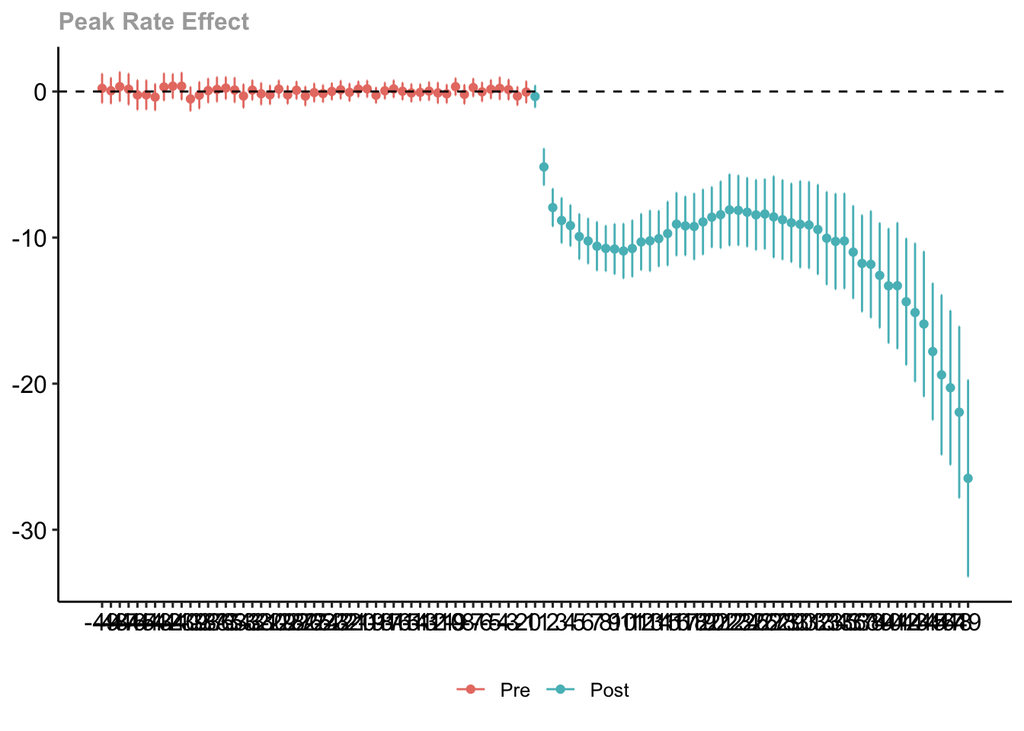

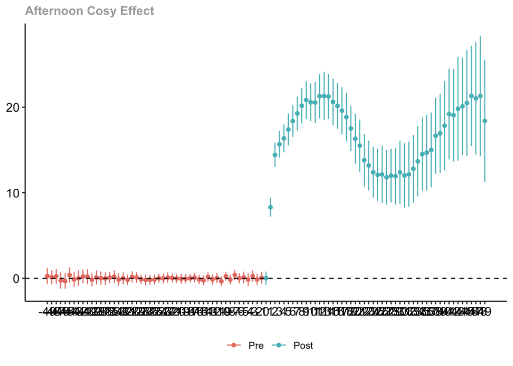

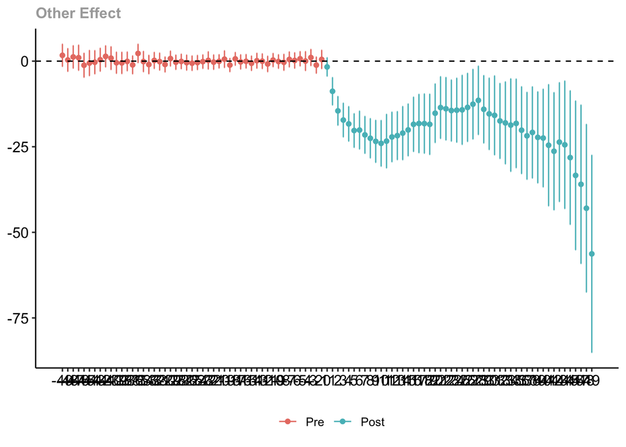

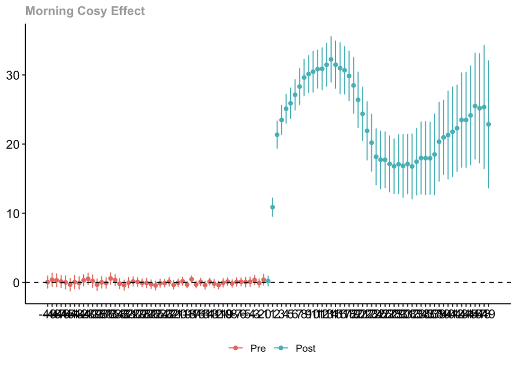

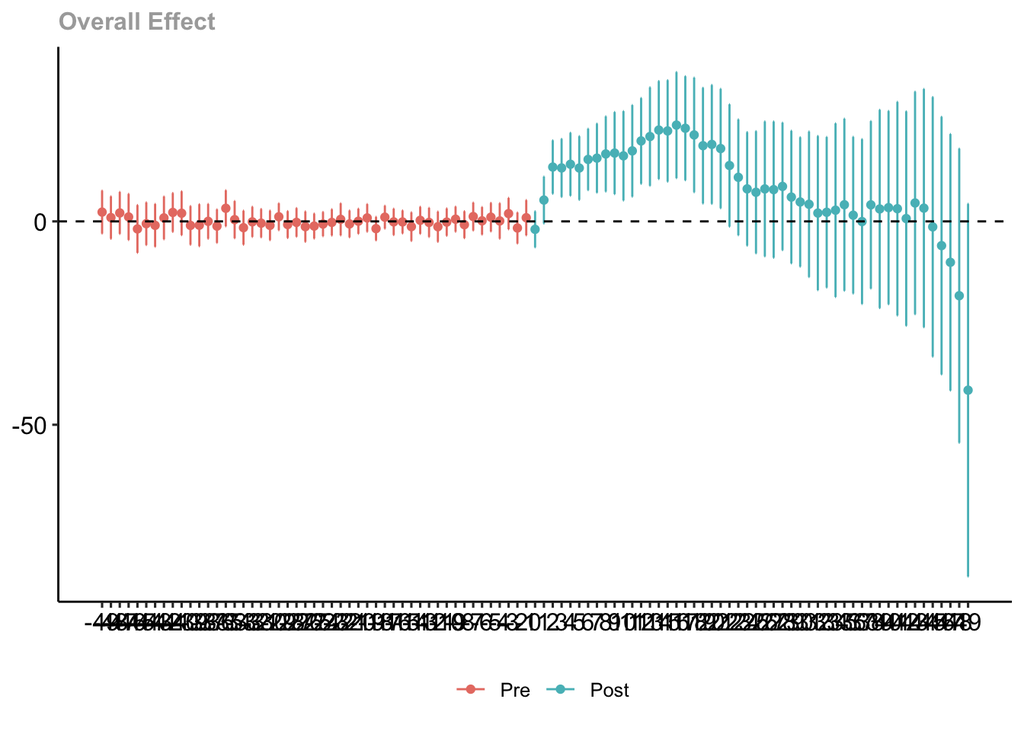

### Group ATT

This looks at the treatment effect within early to later adopters. It’s crucial for understanding if early adopters differed from later adopters.

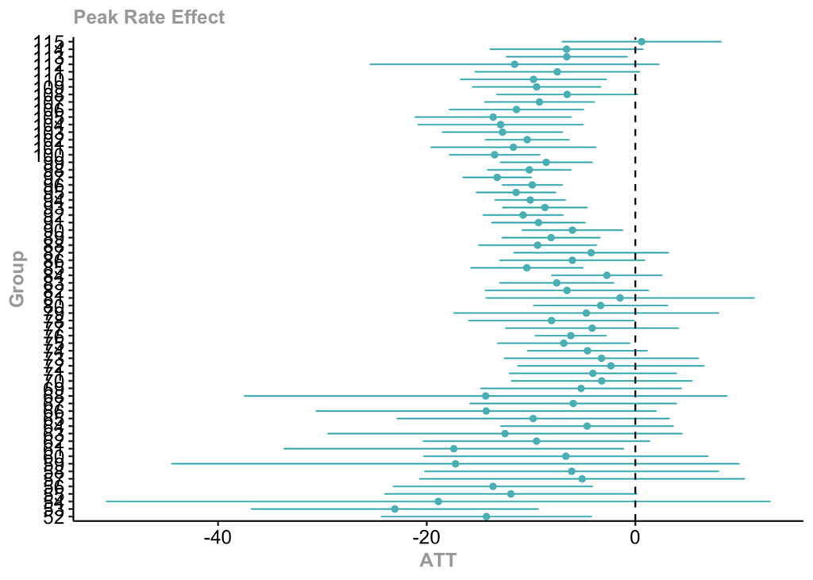

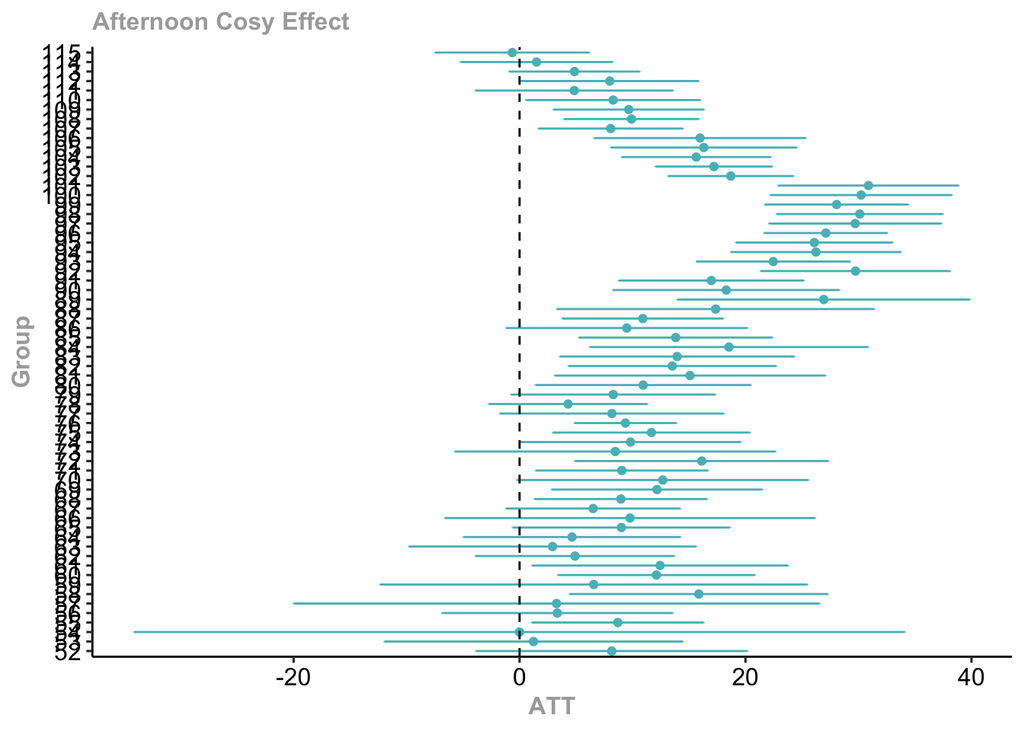

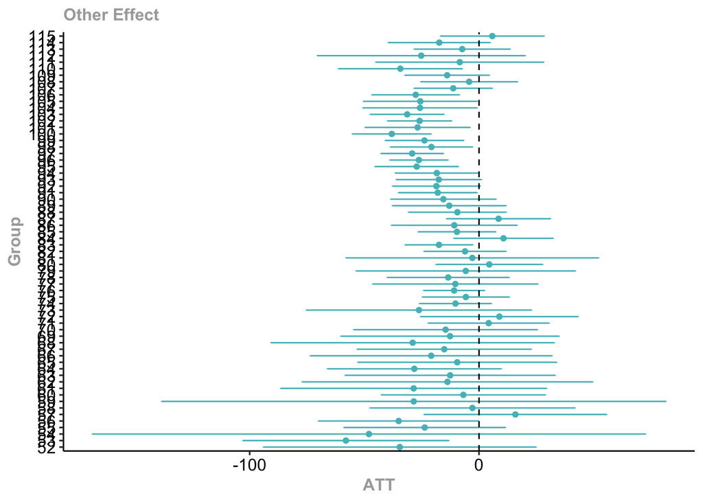

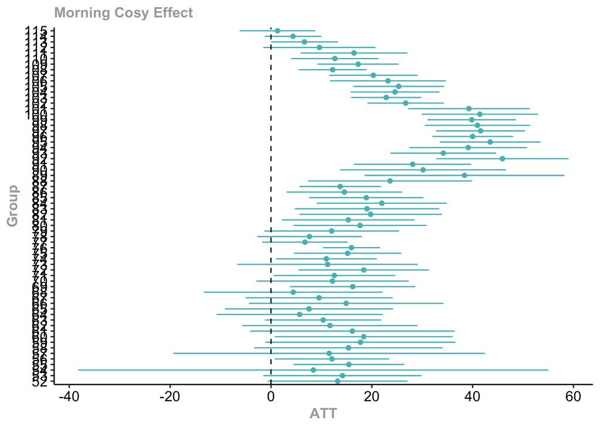

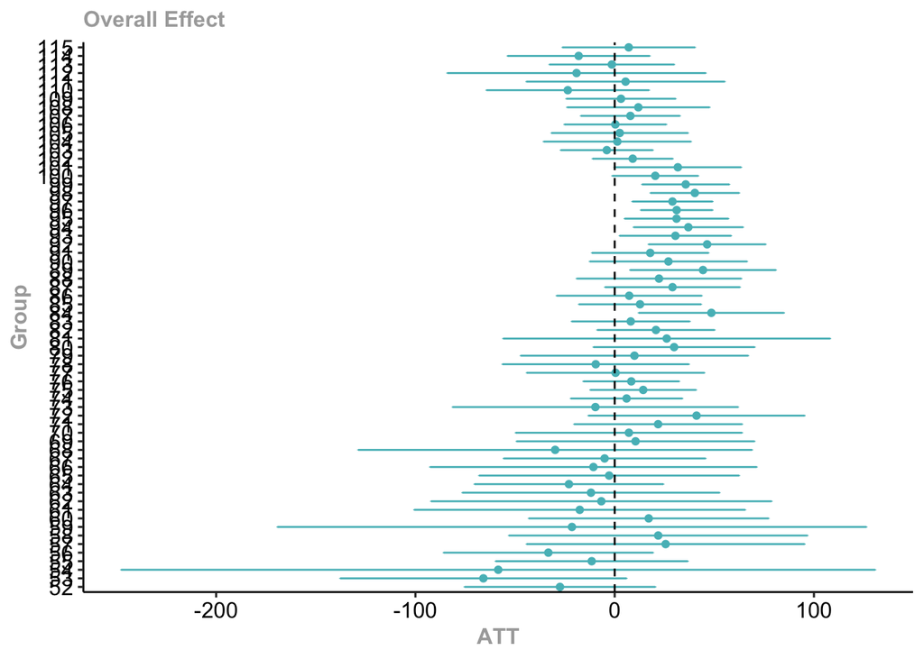

### Calendar ATT

This variation focuses on the treatment effect relative to the calendar time. Unsurprisingly, It shows that the effect of cosy are concentrated during autumn and winter seasons.

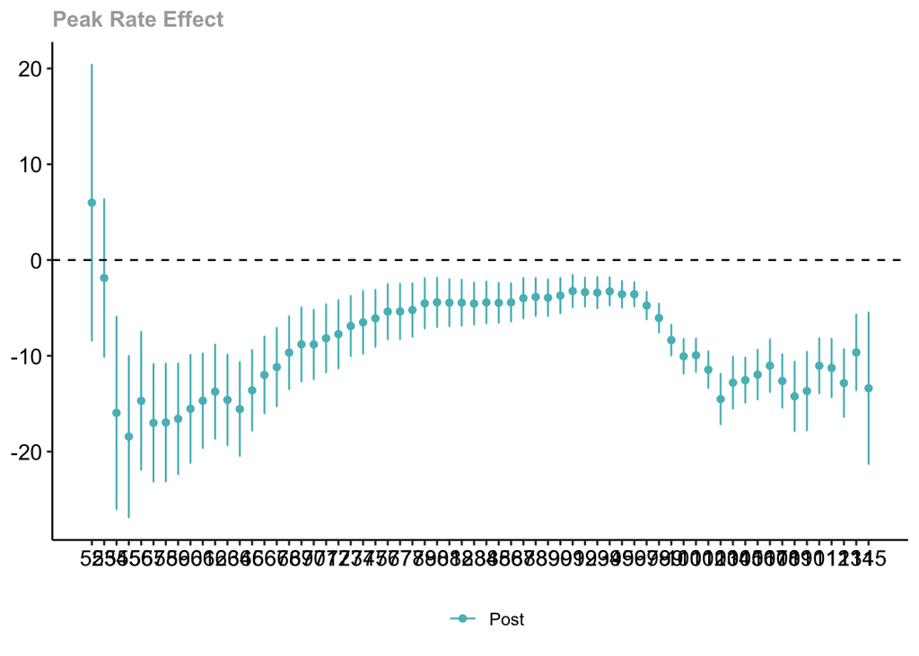

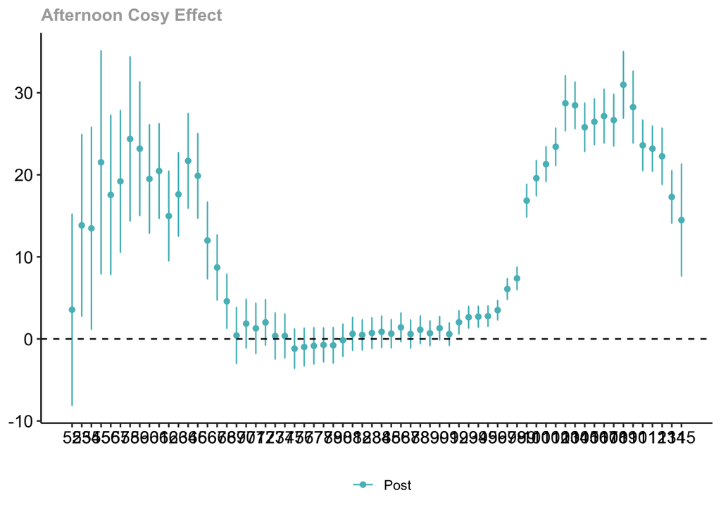

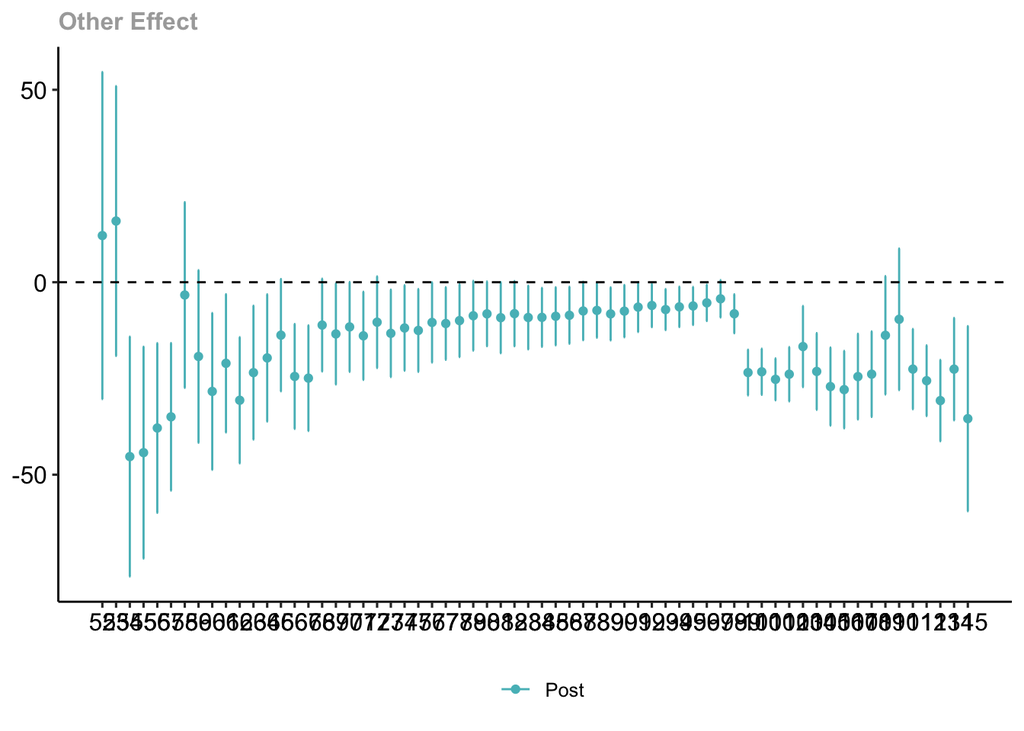

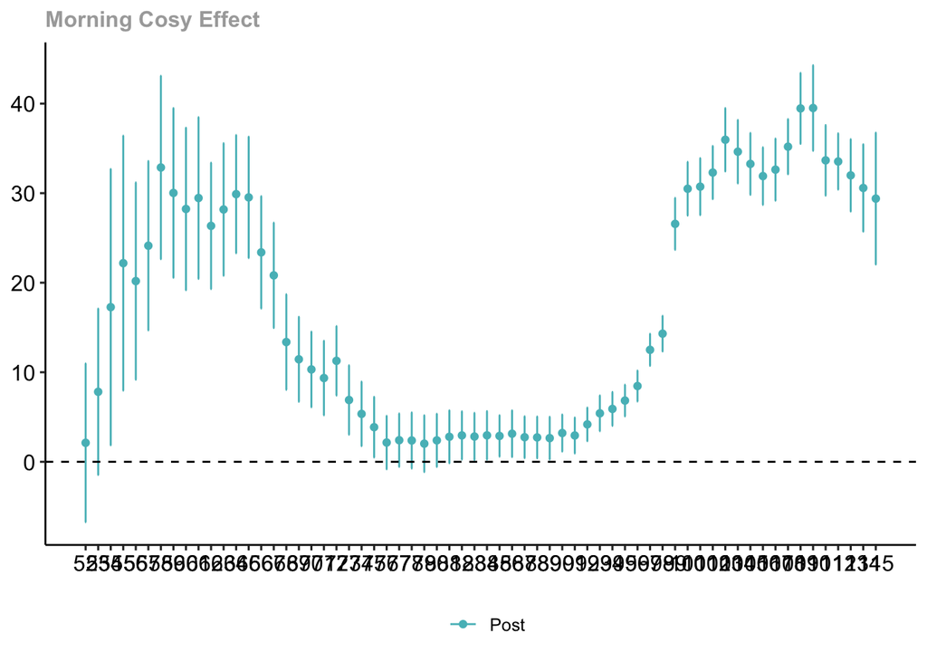

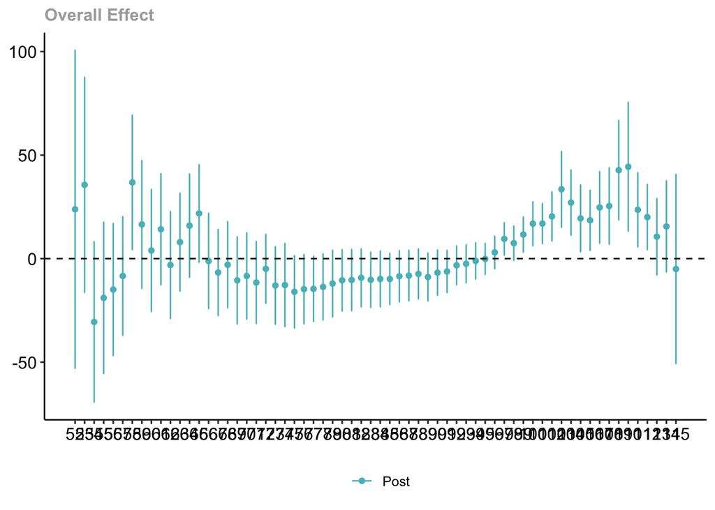

[^1]: I am not sure how Cal constructed the variable